# Assignment 2

STATS 220 Semester One 2022

Magee Ying

03/04/2022

## Introduction

For this survey, I have decided to focus on the musical habits of my respondents. In particular, the amount of time in hours that my respondents spends on music each day, how many favourite artists does my respondents have, when do they listen to music and what genres do they enjoy the most.

## Links to form and data

Click [here](https://docs.google.com/forms/d/14ImIrgx8lMdUc_PHP6Kk6vpa_6xa6h_HIc60sXziDwM/edit) to go to the Google forms survey

Click [here](https://docs.google.com/spreadsheets/d/10LFEroYeKSG89yuWN1YBKqGr_cw5b-703t7aWKhrtPI/edit?resourcekey#gid=870408736) to go to the spreadsheet created from the survey.

Click [here](https://docs.google.com/spreadsheets/d/e/2PACX-1vQtQP0_FPxxXWkozYemuFdoVqMwzbPaKX5ghndlQh3wJsmcn-x0eWUHzcVgOBvK0wchKeWtd4g9O7sg/pub?output=csv) to go to the published csv file.

## Analytics

| Timestamp | music_hours | no_artist | songs_have | fav_genre | background_music |
| --- | --- | --- | --- | --- | --- |
| 4/2/2022 13:55:46 | Less than 1 hour | 10 | 10 | Classical | Yes |
| 4/2/2022 14:13:18 | 2 to 4 hours | 1 | 8000000 | Pop, Classical | Yes |
| 4/2/2022 14:32:58 | 1 to 2 hours | 2 | 21 | Pop | Yes |
| 4/2/2022 14:37:10 | 1 to 2 hours | 3 | 328 | Pop, Classical | No |
| 4/2/2022 14:43:34 | 5 hours or more | 50 | 1318 | Pop, Jazz, Classical, Metal | Yes |

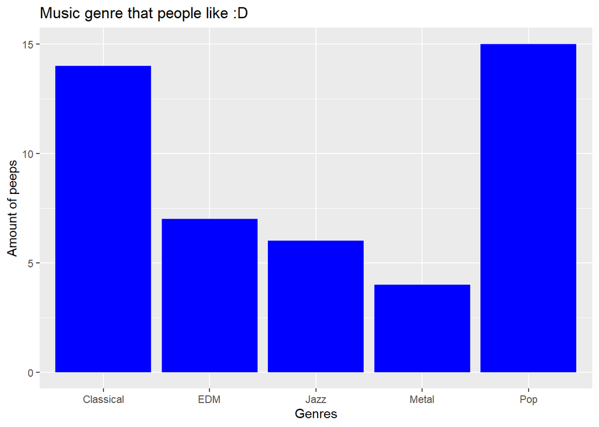

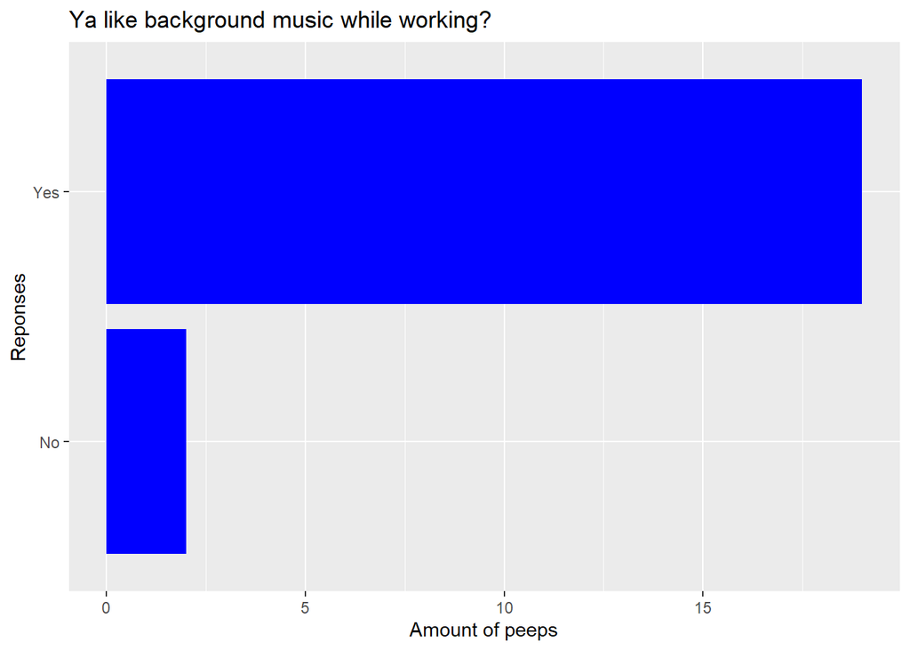

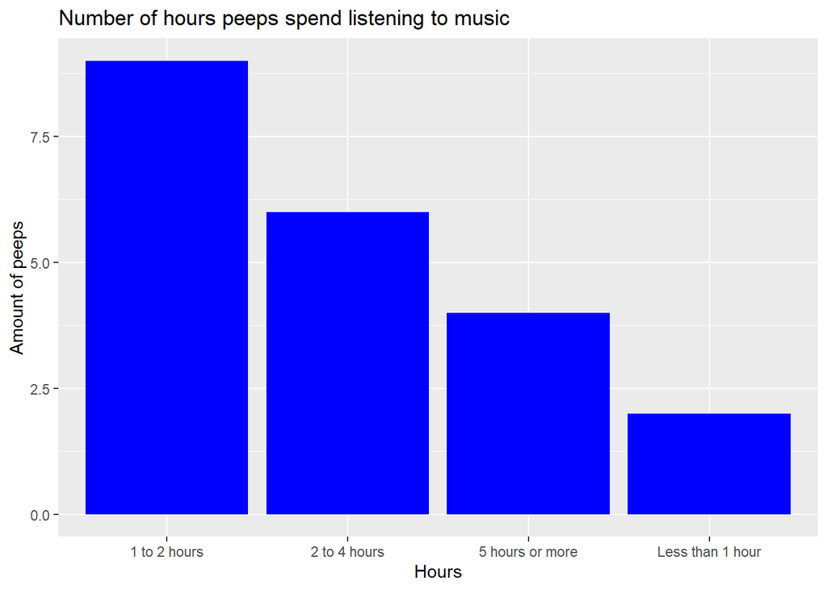

## Learning reflection

From module two of Stats 220, I have learned that using a dynamic survey reporting system is a vital component of any survey on the market. During this assignment, I have reused the skill of CSS chunk in my R Markdown file to stylish my HTML and pipes to make my code clean and efficient. With the skills learned in module two, I can imagine how surveys will become more and more critical for any future company as it plays a huge role for any company to gather information from the population. I do believe that the technique of being able to gather the right data from the right respondents is a crucial skill to have. I am looking forward to a technological future derived from data, where data are everywhere and will be collected for programs that are designed to work out your personal preference based on your background, study status and work status, etc.